# Taralite Take Home Test

Jonathan Christopher

April 29, 2018

### Challenge

Banks play a crucial role in market economies. They decide who can get finance and on what terms and can make or break investment decisions. For markets and society to function, individuals and companies need access to credit.

Credit scoring algorithms, which make a guess at the probability of default, are the method banks use to determine whether or not a loan should be granted. This competition requires participants to improve on the state of the art in credit scoring, by predicting the probability that somebody will experience financial distress in the next two years. The goal of this challenge is to build a model that borrowers can use to help make the best financial decisions.

### Data Dictionary

This are every variable informations that contains in the data set. SeriousDlqin2yrs is indicating the person financial breakdown in the next two years and must be predicted from other variables.

| Variable.Name | Description | Type |
| --- | --- | --- |
| SeriousDlqin2yrs | Person experienced 90 days past due delinquency or worse | Y/N |
| RevolvingUtilizationOfUnsecuredLines | Total balance on credit cards and personal lines of credit except real estate and no installment debt like car loans divided by the sum of credit limits | percentage |
| age | Age of borrower in years | integer |
| NumberOfTime30-59DaysPastDueNotWorse | Number of times borrower has been 30-59 days past due but no worse in the last 2 years. | integer |
| DebtRatio | Monthly debt payments, alimony,living costs divided by monthy gross income | percentage |
| MonthlyIncome | Monthly income | real |
| NumberOfOpenCreditLinesAndLoans | Number of Open loans (installment like car loan or mortgage) and Lines of credit (e.g. credit cards) | integer |
| NumberOfTimes90DaysLate | Number of times borrower has been 90 days or more past due. | integer |
| NumberRealEstateLoansOrLines | Number of mortgage and real estate loans including home equity lines of credit | integer |
| NumberOfTime60-89DaysPastDueNotWorse | Number of times borrower has been 60-89 days past due but no worse in the last 2 years. | integer |
| NumberOfDependents | Number of dependents in family excluding themselves (spouse, children etc.) | integer |

### Data Distribution & Finding Outliers

This section will discuss about missing data, data outliers, and data distribution in every sections. The following data set has a total of 150000 observation of 11 variables. The plot below shows distribution of missing data in the data set.

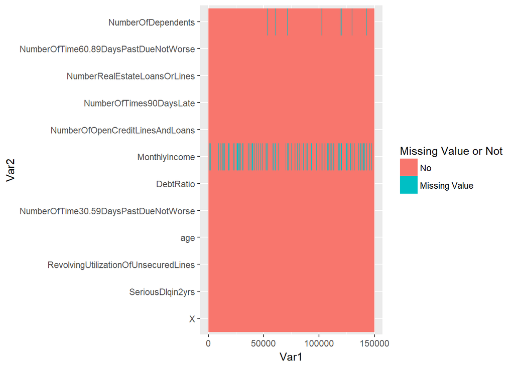

```r
library(ggplot2)
library(magrittr)
library(reshape2)

data_training1 <- read.csv("C:/Users/Jonathan-PC/Documents/Taralite/cs-training.csv", header = TRUE)

data_training1 %>%
  is.na %>%
  melt %>%
  ggplot(aes(x=Var1, y=Var2)) + geom_raster(aes(fill = value)) + scale_fill_discrete(name = "Missing Value or Not", breaks = c("FALSE", "TRUE"), labels = c("No", "Missing Value"))
```

The missing values in the plot are indicated with blue vertical lines and as can be seen that there are missing value in variable **Number of Dependents** and **Monthly Income**. The specific number of missing value in Number of Dependents and Monthly Income are **3924** and **29731**. Let’s take a closer look at the distribution among the variables in the data set.

#### Age

Variable age indicates the distribution of the age of the borrower in the data set. The variable has a normal distribution as can be seen in the histogram below. Age has no missing values and the summary of age is also shown below,

```
##    Min. 1st Qu.  Median    Mean 3rd Qu.    Max.
##     0.0    41.0    52.0    52.3    63.0   109.0
```

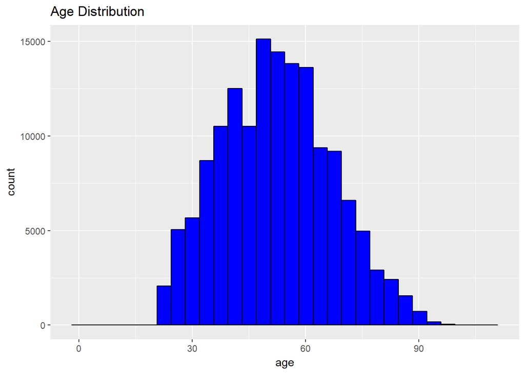

#### Revolving Utilization of Unsecured Lines

Revolving utilization is a term used within the credit world to describe the proportion of your credit card balances to your credit card limits. This variables is a percentage and should have a value between 0 and 1. Value that is < 0 or > 1 will be considered as an outliers. The total number of the outliers in this variable are **3321**.

```
##     Min.  1st Qu.   Median     Mean  3rd Qu.     Max.
##     0.00     0.03     0.15     6.05     0.56 50708.00
```

Because of the outliers the mean value is risen to 6.05 so those outliers will need to be re-value to the median of this variable. The plot below shows the distribution of the variables after the median computation to the outliers.

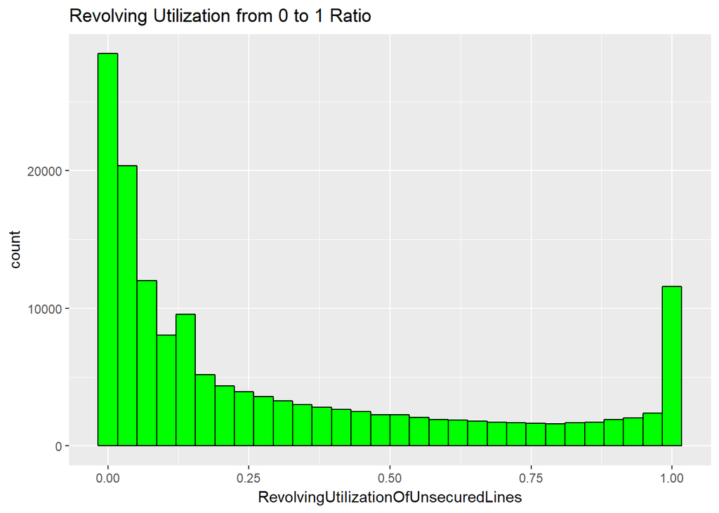

#### Debt Ratio

There are no missing value in this variable but there are some outliers with the value **more than 100000** with the total of 8 borrowers. It can be seen more clearly from the boxplot below,

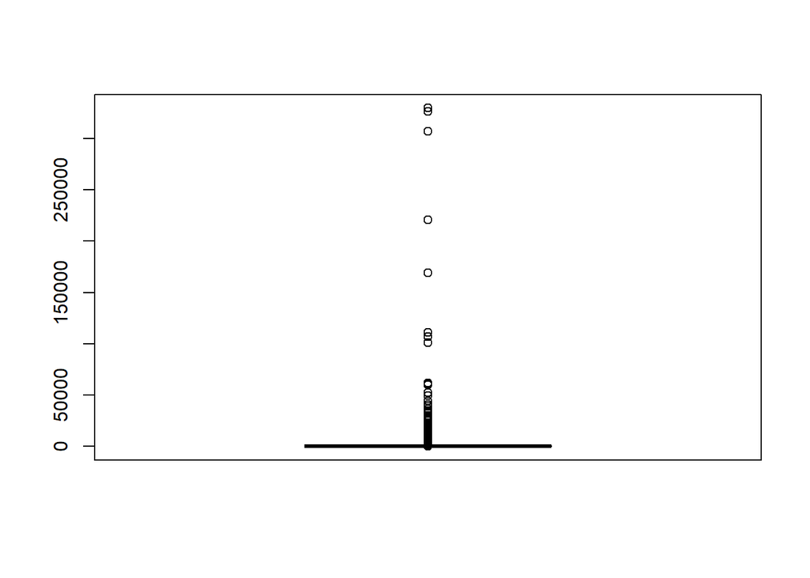

Those outliers will be remove from the data set to increase the accuracy of the data. The summary after some adjustment can be seen below.

```
##     Min.  1st Qu.   Median     Mean  3rd Qu.     Max.
##     0.00     0.18     0.37   341.88     0.87 61907.00
```

#### Monthly Income

The missing value in this variable that has been shown in the first plot is being reimpute to the median of the variables. Additionally, borrower with monthly income **over 300000** are removed from the data set because it was considered an outliers. Below shown the summary of the variable after some adjustment that has been made.

```
##    Min. 1st Qu.  Median    Mean 3rd Qu.    Max.
##       0    3902    5400    6321    7400  287662
```

#### Number of Open Credit Lines and Loans

[output not shown]

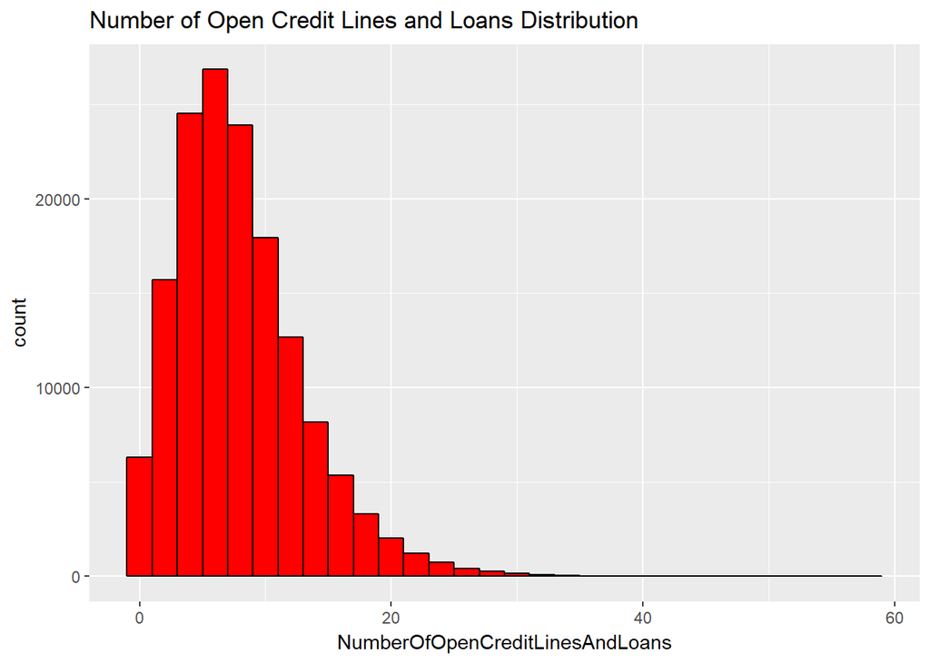

#### Number of Real Estate Loans

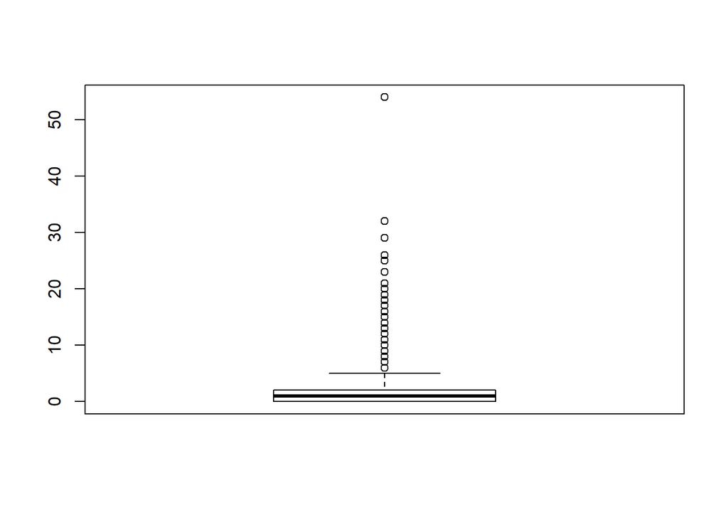

As you can see from the boxplot above, there are one outliers with the value of **54**. Those outliers will be removed from the data set. The plot below indicates the distribution of real estate loans after some adjustment that has been made.

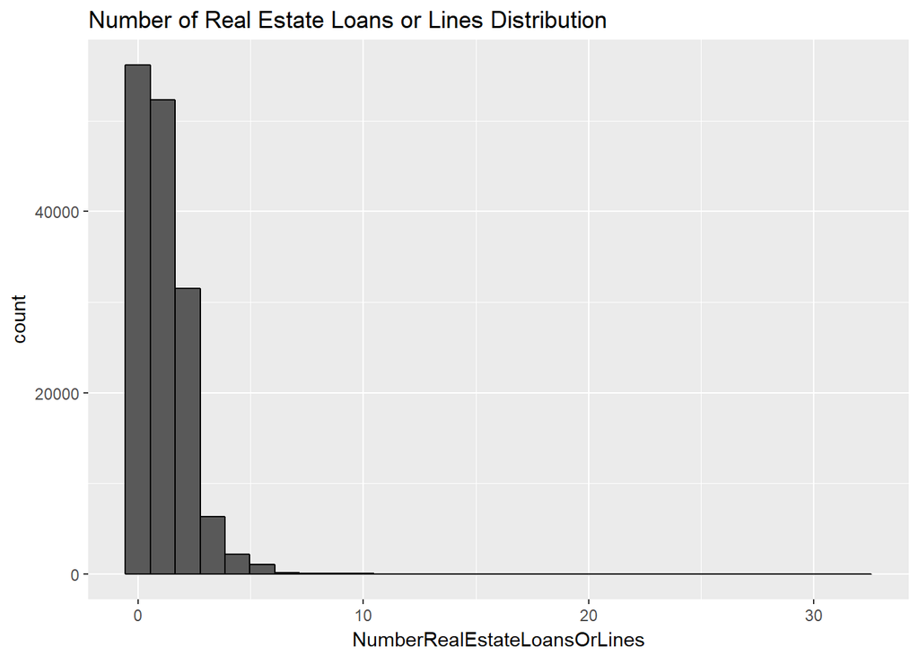

#### Number of Dependents

The missing value from this variable will also be re-value with the value of median. The value of median (0) can be seen below with the summary of the variable and the distribution after some adjustment.

```
##    Min. 1st Qu.  Median    Mean 3rd Qu.    Max.    NA's
##   0.000   0.000   0.000   0.757   1.000  20.000    3922
```

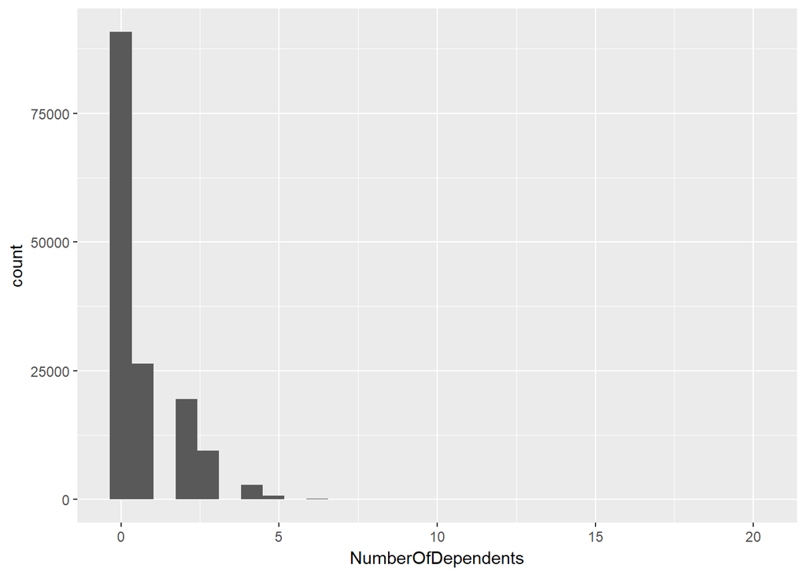

#### Number of Times 30 - 59, 60 - 89 Past Due not Worse, and 90 Days Late

There are same outliers that skewed the mean of the data in this three variables. The value is **96** and **98**. The outliers will be reimpute to the median of those variables which is 0. Below shows the summary after some adjustment from one of three data.

```
##     Min.  1st Qu.   Median     Mean  3rd Qu.     Max.
##  0.00000  0.00000  0.00000  0.09031  0.00000 17.00000
```

The **“cs_test.csv”** data set will also be adjusted so that the data set have no missing value to used for prediction section.

### Down Sampling

The data has an imbalance between two classes which is 0 and 1. Proof that SeriousDlqin2yrs has encountered data imbalance is shown below.

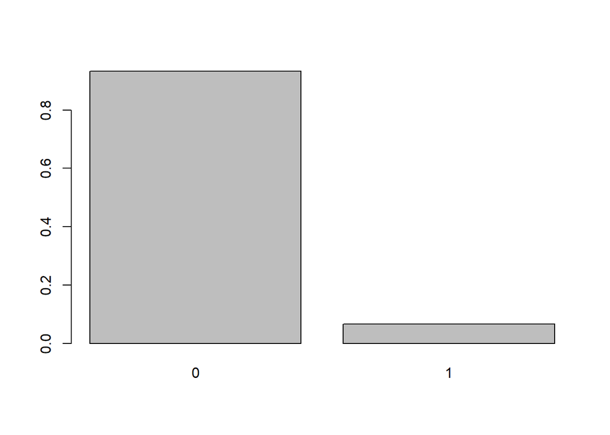

To overcome the imbalance of the data, the 0 class has been **downsampled** to make a new train data that has a almost balance distribution between classes. These are the steps that has been taken to downsampled the data.

```r
newTrain <- data_training1[data_training1$SeriousDlqin2yrs==1,]
DownSampleTrain <- data_training1[data_training1$SeriousDlqin2yrs==0,]
downsampleDat <- sample(1:139948,10500)

newTrainDat<-rbind(newTrain,DownSampleTrain[downsampleDat,])
newTrainDat<-newTrainDat[sample(nrow(newTrainDat)),]
rownames(newTrainDat)<-NULL
```

### Prediction Models

The data is ready to be analyze in some prediction models to predict the outcome of SeriousDlqin2yrs from the cs_test data set. There are three prediction model that has been used in this research that is, Random Forest, Logistic Regression or Generalized Linear Model (GLM), and Gradient Boosting Machine (GBM).

#### Random Forest

Random forest is used to train the model. randomForest package has been used to model the data set. The following parameter is used in the model, **Number of Tree: 500** and **Mtry = 3**.

Thus the syntax below shows the R code of the randomForest model,

```r
library(randomForest)
set.seed(1234)
test_rf <- randomForest(newTrainDat[,-1],              as.factor(newTrainDat$SeriousDlqin2yrs)
          ,do.trace = TRUE, ntree = 500
          ,forest = TRUE)
```

#### Generalized Linear model

```r
library(caret)
glmControl <- trainControl(method = "cv", number = 10, repeats = 10)

set.seed(1234)
test_glm <- train(SeriousDlqin2yrs ~., data = newTrainDat, method = "glm",
                  trControl = glmControl)
```

#### Gradient Boosting Machine

Third, GBM were built to train the data also using the caret package. As the trial and error has been done, the final value used for the model were **Number of Trees: 150** and **Interaction Depth: 3**. The syntax can be seen below,

```r
library(caret)
set.seed(1234)
test_gbm <- train(SeriousDlqin2yrs ~., data = newTrainDat, method = "gbm")
```

### Evaluation

The accuracy from three prediction models that has been used from the section before can be seen in the following table,

| Model | Accuracy |
| --- | --- |
| Random Forest | 78.05% |
| GBM | 77.96% |
| GLM | 76.25% |

Random Forest is the model with the biggest accuracy among the others with the accuracy of **78.05**.

### Results

After the model evalution, we can start predicting the cs_test data set with the following model that has been train. The prediction results from the three models above can be downloaded from the following link, https://drive.google.com/file/d/16lNHumAyng7DXXiNtBFi2ogCQto_V3Y7/view?usp=sharing